# Factors affecting health sector expenditure in OECD countries

Author

Prasanga Paudel

**Authors**

**Author affiliations**

1. College of Agricultural and Environmental Science, University of Georgia, Athens, GA, USA.

$\dagger$ Disclaimer: The opinions expressed in this article are the author’s own and don’t reflect their employer.

# 1 Summary/Abstract

*The data is based on World Development Indicator from World Bank Group. This is a comprehensive database that includes information including employment, public and private expenditure in health sector, fertility, immunization, literacy, mortality, and many more.The dataset has a total of 1496 variables and across 11 years from 2010 to 2020. The actual source of data has information from 1960 to 2023 but to deal with the problem of missing values in recent years and overcomplication in analysis due to too many year data , we will focus on 10 recent years between 2010 and 2020.*

# 2 Introduction

## 2.1 General Background Information

*We will try to analyze the most influential factors affecting the expenditure in health sector by different countries. The predictor variables will include factors ranging from education, mortality, population distribution among rural and urban spaces, and so on. We would use multiple regression analysis with health sector expenditure as dependent variable and the variable of interests as predictors for this panel data.*

*We are using data from OECD members for analysis, and there have already been some research which have focused on GDP as predictor for health sector expenditure. Some research have also focused on the relation between life expectancy and health expenditure. However, these research were based on fixed effect and random effect models. In our analysis we will try to follow OLS multiple regression model.*

## 2.2 Description of data and data source

*This is a time series data based on 38 member countries from the Organisation for Economic Co-operation and Development (OECD). This organization is a unique forum with governments from 37 democracies collaborate to develop policy standards to promote sustainable economic growth. However, the data obtained from this dataset is crude and needs to be treated before attempting analysis based on it. For example, in its present form, the variable name is a long sentense describing the data it contains.The years are listed as column names and variables are listed as Series.*

## 2.3 Objective of the research

The expenditure in health sector is one of the important factor that helps in determining the efficiency of health sector. We can relate the expenditure with different national development indicators and hope to find important connections between them. This will help government to make specific interventions through their policy to enhance their health sector. We can also find out how countries are currently operating and which factor has helped or negatively affected their health sector.

*The main objective of this research is to:*

*1. To analyze the factors that affect the expenditure in health sector among OECD countries.*

*2. To analyze the magnitude of the influence of these factors on health expenditure*

## 2.4 Data aquisition

*The data for this research is available at the official World Bank- Data Bank website.It is a free database managed by world bank group and can be accessed anytime. We can apply various filters as per our need and export the data as a .CSV or an .xlsx file.*

Link to the source: https://databank.worldbank.org/source/world-development-indicators/Type/TABLE/preview/on#

# 3 Methods

We wll be following a panel data time series regression model. The details will be discussed as we progress.

# 4 Importing the original dataset

```r
file_path <- here("data","raw-data", "wdi-oecd.xlsx")
data <- read_excel(file_path, sheet="Data")
```

## 4.1 A look into the original format of the dataset

*This was the state of the data when first downloaded*

```r
head(data)
```

```
# A tibble: 6 × 15
  `Country Name` `Country Code` `Series Name`      `Series Code` `2010 [YR2010]`
  <chr>          <chr>          <chr>              <chr>         <chr>
1 OECD members   OED            Adolescent fertil… SP.ADO.TFRT   31.44760033510…
2 OECD members   OED            Agriculture, fore… NV.AGR.TOTL.… 1.512123631489…
3 OECD members   OED            Annual freshwater… ER.H2O.FWTL.… ..
4 OECD members   OED            Births attended b… SH.STA.BRTC.… 97.77757721482…
5 OECD members   OED            Contraceptive pre… SP.DYN.CONU.… 74.525121400516
6 OECD members   OED            Domestic credit p… FS.AST.DOMS.… ..
# ℹ 10 more variables: `2011 [YR2011]` <chr>, `2012 [YR2012]` <chr>,
#   `2013 [YR2013]` <chr>, `2014 [YR2014]` <chr>, `2015 [YR2015]` <chr>,
#   `2016 [YR2016]` <chr>, `2017 [YR2017]` <chr>, `2018 [YR2018]` <chr>,
#   `2019 [YR2019]` <chr>, `2020 [YR2020]` <chr>
```

# 5 Importing the cleaned dataset

```r
#Path to data.
data_location <- here::here("data","processed-data","processeddata.rds")
#load data
mydata <- readRDS(data_location)
```

## 5.1 A look into the cleaned dataset

*This is the present state of the dataset*

```r
head(mydata)
```

```
# A tibble: 6 × 1,501
  CountryName CountryCode Year  SeriesCode     Adolescent_fertility_rate_birth…¹
  <chr>       <chr>       <chr> <chr>          <chr>
1 Australia   AUS         2010  VC.IHR.PSRC.P5 17.069
2 Australia   AUS         2011  VC.IHR.PSRC.P5 16.307
3 Australia   AUS         2012  VC.IHR.PSRC.P5 16.038
4 Australia   AUS         2013  VC.IHR.PSRC.P5 14.697
5 Australia   AUS         2014  VC.IHR.PSRC.P5 13.072
6 Australia   AUS         2015  VC.IHR.PSRC.P5 12.038
# ℹ abbreviated name:
#   ¹Adolescent_fertility_rate_births_per_1000_women_ages_1519
# ℹ 1,496 more variables:
#   Agriculture_forestry_and_fishing_value_added__of_GDP <chr>,
#   Annual_freshwater_withdrawals_total__of_internal_resources <chr>,
#   Births_attended_by_skilled_health_staff__of_total <chr>,
#   Contraceptive_prevalence_any_method__of_married_women_ages_1549 <chr>, …
```

# 6 Results

In exploratory data analysis, we will just look at data from Australia as a reference for relation between variables in most of the cases. We are currently thinking of using “Current Health Expenditure as a % of GDP” as our dependent variable. But, we will see the it’s distribution and connections with other variables before making decision.

## 6.1 Exploratory/Descriptive analysis

*Here, we will now use a combination of tables and figues to have a look into the data.*

As this is a time series data, it is quite difficult to visualize all the variables across the years for all the countries. So, we will try to keep it simple and see simple relations between variables within a year or trend of a particular variable for some countries across the years.

Table 1 shows the values under interesting variables for all OECD countries for the year 2010.

Table 1: Summary of variables

| CountryName | National Development Indicators GDP_current_US | National Development Indicators Population_total | National Development Indicators Life_expectancy_at_birth_total_years | National Development Indicators Physicians_per_1000_people | National Development Indicators Hospital_beds_per_1000_people | National Development Indicators Government_Effectiveness_Estimate | National Development Indicators Control_of_Corruption_Estimate | National Development Indicators Rule_of_Law_Estimate | National Development Indicators Access_to_electricity__of_population | National Development Indicators Unemployment_total__of_total_labor_force_modeled_ILO_estimate | National Development Indicators Poverty_headcount_ratio_at_national_poverty_lines__of_population |
| --- | --- | --- | --- | --- | --- | --- | --- | --- | --- | --- | --- |
| Australia | 1148838233480.7195 | 22031750 | 81.695121951219534 | 3.364 | 3.78 | 1.76339137554169 | 2.02361083030701 | 1.75771832466125 | 100 | 5.214 | .. |
| Austria | 389827789217.63409 | 8363404 | 80.580487804878061 | 4.808 | 7.65 | 1.81252110004425 | 1.59612202644348 | 1.80120265483856 | 100 | 4.883 | 14.5 |
| Belgium | 481556503720.00092 | 10895586 | 80.1829268292683 | 2.925 | 6.13 | 1.65420985221863 | 1.47382998466492 | 1.41785252094269 | 100 | 8.293 | .. |
| Canada | 1617343367486.2585 | 34005902 | 81.322195121951225 | 2.0384 | 2.79 | 1.77782678604126 | 2.06187319755554 | 1.79859042167664 | 100 | 8.178 | .. |
| Chile | 217051209240.29752 | 17181464 | 78.501 | 1.438 | 2.05 | 1.15724182128906 | 1.44162690639496 | 1.22541570663452 | 99.5 | 8.278 | .. |
| Colombia | 286498534094.96326 | 44777319 | 75.033 | 1.664 | 1.51 | -0.123824141919613 | -0.42333310842514 | -0.271385610103607 | 96.8 | 11.153 | .. |
| Costa Rica | 37658616951.803787 | 4555962 | 78.67 | 2.283 | 1.21 | 0.298928886651993 | 0.66439163684845 | 0.535760879516602 | 99 | 7.171 | .. |
| Czechia | 211168667286.26968 | 10474410 | 77.424390243902451 | 3.599 | 7.3 | 0.9017294049263 | 0.384590119123459 | 0.930919170379639 | 100 | 7.281 | 9.8 |
| Denmark | 322345594075.47015 | 5547683 | 79.100000000000009 | 3.724 | 3.5 | 2.10007047653198 | 2.35235905647278 | 1.89844179153442 | 100 | 7.746 | .. |
| Estonia | 19524355419.037971 | 1331475 | 75.429268292682934 | 3.244 | 5.27 | 1.07666647434235 | 0.989536285400391 | 1.15312993526459 | 100 | 16.707 | 17.5 |
| Finland | 249429613683.3338 | 5363352 | 79.870731707317091 | 3.184 | 5.86 | 2.22388696670532 | 2.15166974067688 | 1.96125268936157 | 100 | 8.394 | 13.7 |
| France | 2646230027988.3384 | 65026211 | 81.663414634146349 | 3.397 | 6.67 | 1.46266102790833 | 1.48775613307953 | 1.49973154067993 | 100 | 9.279 | .. |
| Germany | 3468154343000.0068 | 81776930 | 79.987804878048792 | 3.734 | 8.29 | 1.51569378376007 | 1.76642882823944 | 1.63750469684601 | 100 | 7.043 | .. |
| Greece | 296417644404.03387 | 11121341 | 80.3878048780488 | 5.803 | 4.52 | 0.492912799119949 | -0.0625116676092148 | 0.583895683288574 | 100 | 12.719 | 21.4 |
| Hungary | 132175349953.71332 | 10000023 | 74.207317073170742 | 2.872 | 7.19 | 0.644822657108307 | 0.303954064846039 | 0.77266937494278 | 100 | 11.172 | 14.1 |
| Iceland | 13751161917.739773 | 318041 | 81.89756097560975 | 3.588 | 3.58 | 1.580402135849 | 1.93496966362 | 1.70661580562592 | 100 | 7.564 | 9.2 |
| Ireland | 221985621537.50043 | 4560155 | 80.743902439024382 | 4.164 | 2.75 | 1.34430372714996 | 1.68115770816803 | 1.76081323623657 | 100 | 14.534 | .. |
| Israel | 238912622309.59021 | 7623600 | 81.60243902439025 | 3.519 | 3.29 | 1.38622903823853 | 0.750026702880859 | 0.909712016582489 | 100 | 8.48 | .. |
| Italy | 2144936254535.0042 | 59277417 | 82.036585365853668 | 3.784 | 3.61 | 0.467300355434418 | 0.283443719148636 | 0.454773187637329 | 100 | 8.363 | 19.8 |
| Japan | 5759071769013.1133 | 128070000 | 82.842682926829269 | 2.213 | 13.51 | 1.52235090732574 | 1.55362319946289 | 1.31965863704681 | 100 | 5.102 | .. |
| Korea, Rep. | 1143672241149.7156 | 49554112 | 80.117073170731715 | 2.014 | 8.87 | 1.14781618118286 | 0.426656723022461 | 1.00820755958557 | 100 | 3.324 | .. |
| Latvia | 23468324572.334278 | 2097555 | 73.4829268292683 | 3.101 | 5.67 | 0.722773253917694 | 0.203808978199959 | 0.758604049682617 | 99.8 | 19.482 | 19 |
| Lithuania | 36638128534.064323 | 3097282 | 73.268292682926827 | 3.895 | 7.07 | 0.738227605819702 | 0.37242180109024 | 0.776326060295105 | 99.7 | 17.814 | 19.2 |
| Luxembourg | 56213985987.416779 | 506953 | 80.631707317073179 | 2.773 | 5.37 | 1.71641802787781 | 2.03858494758606 | 1.84410035610199 | 100 | 4.423 | .. |
| Mexico | 1105424238731.0928 | 113623895 | 74.19 | 2.026 | 1.06 | 0.0962913855910301 | -0.439748138189316 | -0.552031338214874 | 99.2 | 5.303 | .. |
| Netherlands | 852464982433.335 | 16615394 | 80.702439024390245 | 2.963 | 4.12 | 1.77032697200775 | 2.09006071090698 | 1.81173205375671 | 100 | 4.991 | .. |
| New Zealand | 146517541181.254 | 4350700 | 80.904878048780489 | 2.626 | 2.75 | 1.81132459640503 | 2.32940340042114 | 1.86188757419586 | 100 | 6.557 | .. |
| Norway | 431052143940.43817 | 4889252 | 80.997560975609773 | 4.114 | 4.3 | 1.87354242801666 | 2.07725214958191 | 1.88987576961517 | 100 | 3.527 | .. |
| Poland | 478111630683.5141 | 38042794 | 76.246341463414637 | 2.156 | 6.51 | 0.630121886730194 | 0.513736724853516 | 0.712359011173248 | 100 | 9.578 | .. |
| Portugal | 238443864993.21713 | 10573100 | 79.026829268292687 | 3.979 | 3.37 | 0.981475114822388 | 1.06266355514526 | 1.02578413486481 | 100 | 10.771 | 18 |
| Slovak Republic | 91112160800.766846 | 5391428 | 75.112195121951217 | 3.356 | 6.46 | 0.781369268894196 | 0.248165294528008 | 0.563034415245056 | 100 | 14.387 | 13 |
| Slovenia | 47793117240.900093 | 2048583 | 79.4219512195122 | 2.42 | 4.55 | 1.01478588581085 | 0.917391359806061 | 1.00198233127594 | 100 | 7.236 | 13.6 |
| Spain | 1427989078916.6694 | 46576897 | 81.6268292682927 | 3.758 | 3.11 | 0.942974150180817 | 1.16003704071045 | 1.15678811073303 | 100 | 19.86 | 20.6 |
| Sweden | 492753255885.71826 | 9378126 | 81.451219512195138 | 3.806 | 2.73 | 1.96262037754059 | 2.21972584724426 | 1.93030881881714 | 100 | 8.61 | 15.4 |
| Switzerland | 598851028906.58032 | 7824909 | 82.246341463414652 | 3.81 | 5.2 | 1.8709591627121 | 2.06414246559143 | 1.74979496002197 | 100 | 4.808 | 15 |
| Turkiye | 776967266305.53027 | 73142150 | 75.069 | 1.687 | 2.74 | 0.315034985542297 | 0.0254152249544859 | 0.0499801225960255 | 100 | 11.879 | .. |
| United Kingdom | 2485482596184.7095 | 62766365 | 80.402439024390247 | 2.656 | 2.93 | 1.6179975271225 | 1.60567390918732 | 1.77469253540039 | 100 | 7.924 | .. |
| United States | 15048971000000 | 309327143 | 78.541463414634151 | .. | 3.03 | 1.55227208137512 | 1.26525807380676 | 1.63102221488953 | 100 | 9.633 | .. |
| NA | NA | NA | NA | NA | NA | NA | NA | NA | NA | NA | NA |

### 6.1.1 Looking into the trend for our possible dependent variable

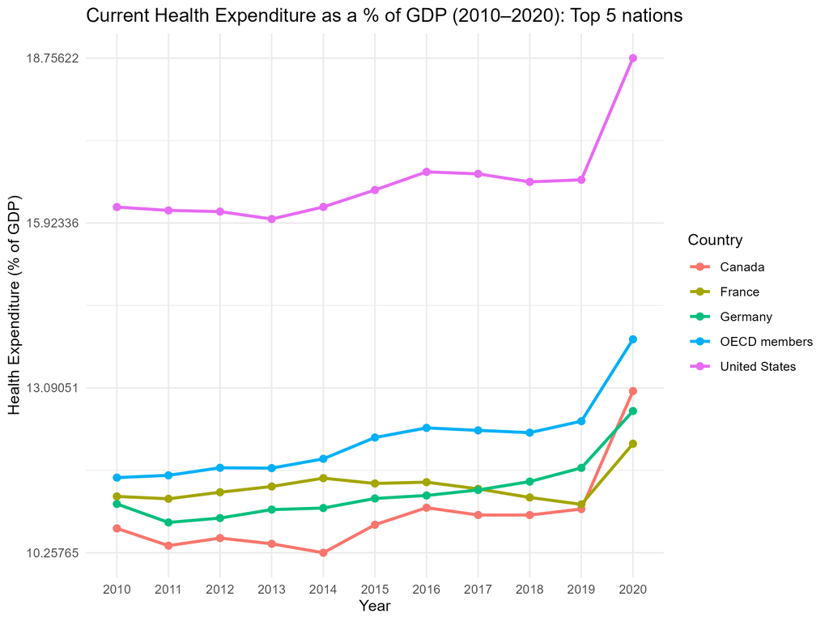

Figure 2 shows the distribution of “Health Expenditure as a Percentage of GDP changes over time for Australia.

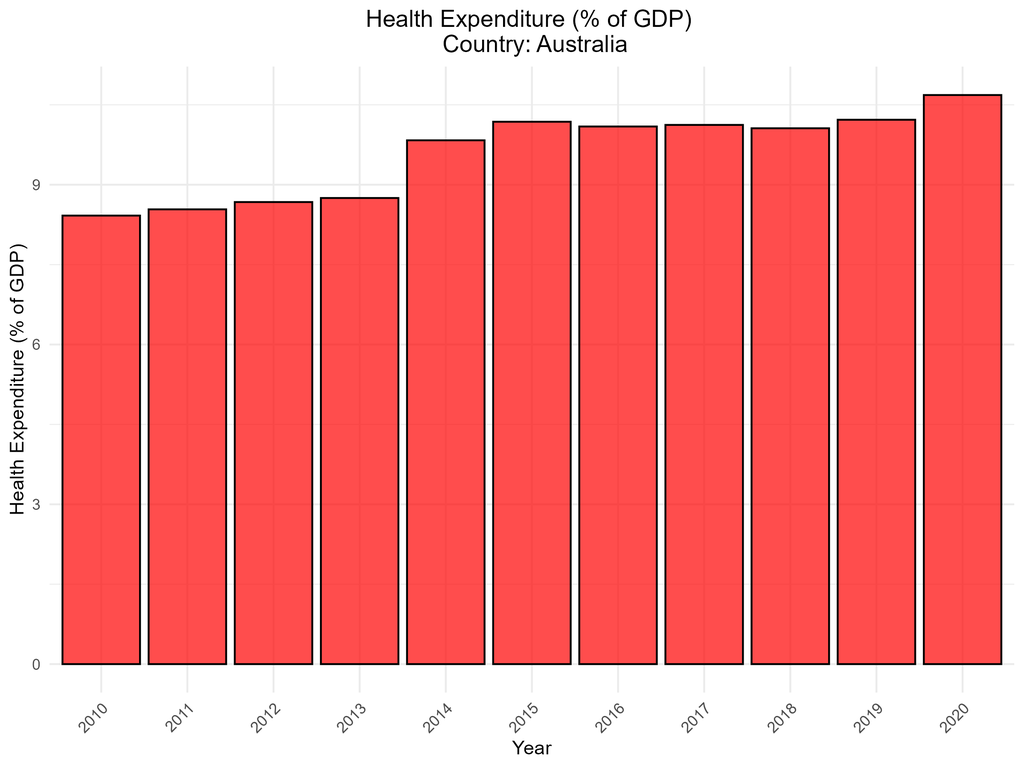

Figure 2: Health Expenditure (% of GDP), Country: Australia

Figure 3 shows the distribution of Health Expenditure as a Percentage of GDP over the Years Comparing with shows any reation with annual population growth for Australia.This figure shows that it has very less in common with Figure 2 as long as distribution and correlation is concerned.

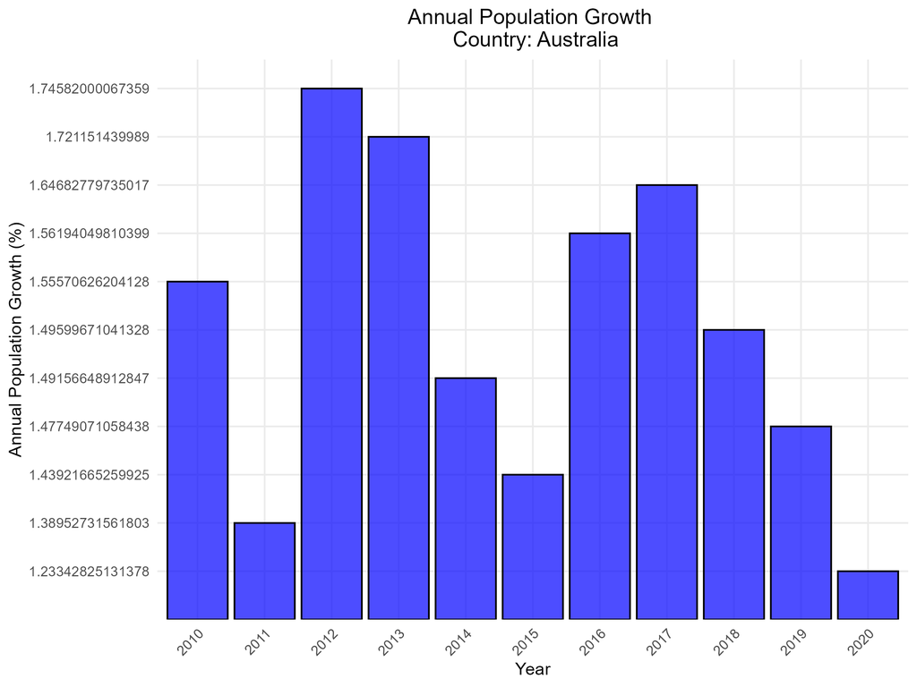

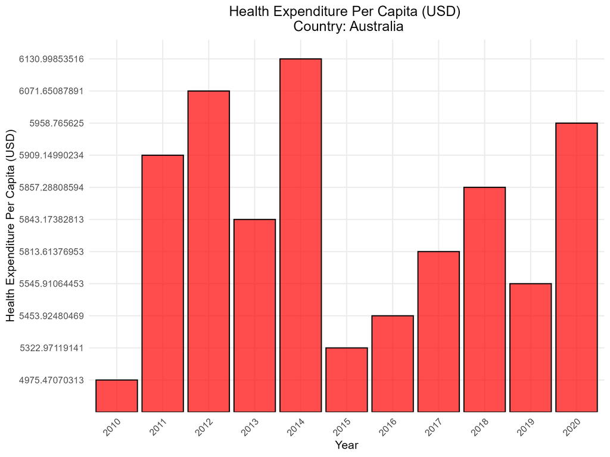

Figure 4: Health Expenditure Per Capita (USD, Country: Australia

# 7 Discussion

## 8 References

1.

McKay B, Ebell M, Billings WZ, et al. [Associations Between Relative Viral Load at Diagnosis and Influenza A Symptoms and Recovery.](https://doi.org/10.1093/ofid/ofaa494) *Open forum infectious diseases*. 2020;7(11):ofaa494.

2.

McKay B, Ebell M, Dale AP, et al. [Virulence-mediated infectiousness and activity trade-offs and their impact on transmission potential of influenza patients.](https://doi.org/10.1098/rspb.2020.0496) *Proceedings. Biological sciences*. 2020;287(1927):20200496.

3.

Leek JT, Peng RD. [Statistics. What is the question?](https://doi.org/10.1126/science.aaa6146) *Science (New York, N.Y.)*. 2015;347(6228):1314–1315.